# Abstract

# Introduction

This document was structured as follows:

The Running tests & finding bugs four first sessions are related to the four first sessions of Results they contain tests and/or detailed explanations about how I obtained my results, the last session on Running tests & finding bugs, General analysis, is about a myriad of tools I've used to run tests on Webcompat and its results.

The Future implementations in details session consists in things that I thought I could improve but I didn't have the time to implement.

The Timeline session contains what I intend to produce in case I get approved on Outreachy.

# Motivation

Performance is a key characteristic for a webpage, according to a [research](https://dzone.com/articles/google-53-of-mobile-users-abandon-sites-that-take) made by Google a few years ago 53% of mobile users abandon sites that take longer than 3 seconds to load its first paint and desktop users too aren't willing to spend much longer whatching a screen loads, according to Fiona Fui-Hoon's [work](http://sighci.org/uploads/published_papers/bit04/BIT_Nah.pdf), the average user will wait approximately 2 seconds.

This work intends to improve rendering of webcompat.com by exploring a number of tools and solutions on frontend and backend.

# Running tests & finding bugs

One thing I realized while making tests is that you can get a hot cache from Github, that means that if I test a lot of things in sequence I'll get a better result than testing one thing and then waiting for a while before testing it again. I tried to minimize the differences between these two states by testing everything using Github's hot cache. Also, before each new test I've refreshed the page a couple of times and looked at the general statistics so I could remove outliers (for better or for worse), for example, if a page usually takes 1s to load but in one of my tests it took 5s than I'd know something out of ordinary happened and I wouldn't use this result on my analysis. I know it's not the ideal scenario but it was the best solution I could come with until now (profiling is hard!).

## HTTP 2

Results I've obtained running Webcompat on a Ngnix 1.15.5 server using uWSGI 2.0.17.1 to make HTTP/2 requests:

**Mac homepage**

| Analysis | HTTP/1.1 | HTTP/2 | HTTP/2 + push |
| --- | --- | --- | --- |
| Load requests | 490ms | 463ms | 402ms |
| First paint | 508ms | 472ms | 430ms |

**Mac new issue**

| Analysis | HTTP/1.1 | HTTP/2 | HTTP/2 + push |
| --- | --- | --- | --- |
| Load requests | 424ms | - | 352ms |
| First paint | 444ms | - | 317ms |

**Nexus homepage**

| Analysis | HTTP/1.1 | HTTP/2 | HTTP/2 + push |
| --- | --- | --- | --- |
| Load requests | 1153ms | 1288ms | 950ms |
| First paint | 1343ms | 1740ms | 1105ms |

**Nexus new issue**

| Analysis | HTTP/1.1 | HTTP/2 | HTTP/2 + push |
| --- | --- | --- | --- |
| Load requests | 450ms | - | 429ms |
| First paint | 1060ms | - | 650ms |

**Sony homepage**

| Analysis | HTTP/1.1 | HTTP/2 | HTTP/2 + push |
| --- | --- | --- | --- |
| Load requests | 760ms | 780ms | 680ms |
| First paint | 811ms | 755ms | 730ms |

**Sony new issue**

| Analysis | HTTP/1.1 | HTTP/2 | HTTP/2 + push |
| --- | --- | --- | --- |
| Load requests | 701ms | - | 452ms |
| First paint | 634ms | - | 474ms |

I've experimented with three different approaches, the first one using plain HTTP/1.1, this approach emulates the real Webcompat server, then I tried a plain HTTP/2 approach in which I've simply added the word http2 to `listen 443 ssl http2;` and finally I thought it'd be a good idea to use `push` to common files like `webcompat.min.css` and `webcompat.min.js`, so I've added the following lines to server:

```
http2_push /css/dist/webcompat.min.css;
http2_push /js/dist/webcompat.min.js?bd3a7d264933c78b0dbd5f35d1f077c3;
http2_push_preload on;
```

These changes can be checked in this [commit](https://github.com/marimeireles/webcompat.com/commit/8ca270fa8b49eae97bfabd7a1d10e75b4bd628cd).

The load requests line in the table refers to the time the website took to load all of the requests necessary to render the first paint. On homepage and on new issue page the necessary files were the same: open sans font, `webcompat.min.css`, `ga.js`, `analytics.js`, `webcompat.min.js`, `untriaged.js` and the .svg leaves.

While building the server at my local machine I had some issues with my authentication with Github I didn't have much time so I decided to test pages that weren't very dependent on that, because of this issue I wasn't able to fetch any Github issues.

I ran the tests on the homepage first and then I realized my changes with push always performed better so when I tested the new issue page I didn't run tests using HTTP2 only because I knew they would perform worse.

## Markdown-it

These tests were made using a Nexus 5 with the same setup as described at List of issues setup and the option Fast 3G available on Chrome DevTools checked.

| Subpage | Total load time | DOM content load | Load time | TTFP | Parse HTML |
| --- | --- | --- | --- | --- | --- |
| Homepage original | 7080ms | 4777ms | 4775ms | 2200ms | 166ms |
| Homepage modified | 6102ms | 3757ms | 3752ms | 2112ms | 99ms |
| Issues original | 6782ms | 5040ms | 5026ms | 2238ms | 477ms |
| Issues modified | 6012ms | 3776ms | 3768ms | 2240ms | 343ms |

Box plots generated with data gathered on issues:

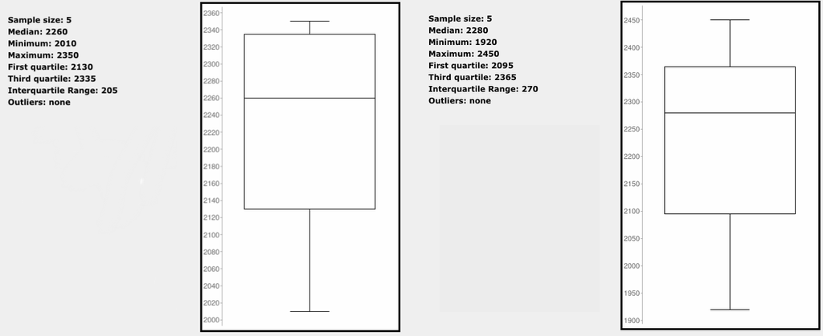

## List of issues

The following table was generated using the data sampled from 70 tests. 35 using my modified code and 35 not. I removed outliers and this is what I got:

| Status | First painting | Parse loading(ms) | Parse loading(%) | XHR loading(ms) | XHR loading(%) |
| --- | --- | --- | --- | --- | --- |
| Non-optimal | 1083ms | 620ms | 40% | 399ms | 32% |
| Optimal | 956ms | 304ms | 20% | 416ms | 28% |

This data was generated using a Nexus 5 connected on a MacBook running `Chrome/69.0.3497.100`. To be able to do that I had to add a few lines of code that can be found on this [PR](https://github.com/webcompat/webcompat.com/pull/2669).

I've noticed that there are some differences in the development and production environment, for example, a lot of files that aren't minified in dev are minified in production. So what I did was change the environment from development to production using `export DEVELOPMENT=1` and change my `secrets.py` file to `if True` instead of `if env.LOCALHOST` so I could test the production environment while I was running the server on my computer. What I learned from doing that is that my result was consistent, it doesn't matter if I'm on development environment or on production.

## Homepage

I ran 30 tests, 10 times for each line of the following table. I've used the same method as described on List of issues to make the tests.

| Status | First painting |
| --- | --- |
| No changes | 1079ms |
| bugform.js | 941ms |
| bugform.js & untriaged.js | 1159 |

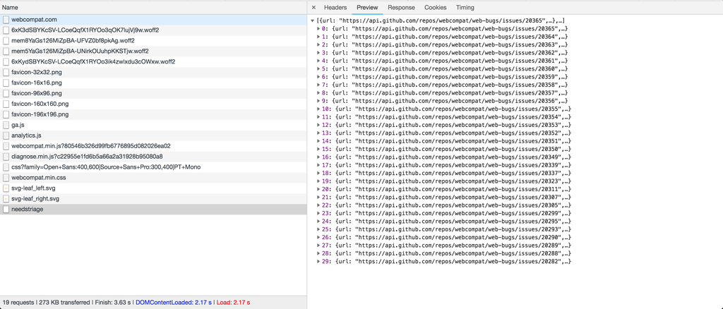

Size and waiting time decrease because of fewer issues being downloaded:

| #Issues | Size(kb) | Waiting Time(ms) |
| --- | --- | --- |
| 30 | 136kb | 991ms |
| 5 | 23kb | 681ms |

## All changes applied

After applying all the optimizations above I got the following results:

| Subpage | Total load time | DOM content load | Load time | TTFP |
| --- | --- | --- | --- | --- |
| Homepage original | 3059ms | 1823ms | 1820ms | 1343ms |
| Homepage modified | 1370ms | 953ms | 1008ms | 1088ms |
| New issue original | 1866ms | 1633ms | 1760ms | 1060ms |
| New issue modified | 1316ms | 1008ms | 1280ms | 807ms |

I ran five tests for each of the lines in the table using my Nexus 5 and the Fast 3G option available on the Chrome DevTools menu.

## General analysis

### Test my site

Since websites tends to have a worse performance on non-desktop devices I chose to start my research on mobile. I've chosen to start with simple and more direct tests first to understand the most obvious and easy to fix system issues.

The first software I used was [Test my site](https://testmysite.thinkwithgoogle.com). Test my site is a website powered by the technology of [Web page test](https://www.webpagetest.org) which is an open source software endorsed by the [community](https://www.2dogsdesign.com/how-to-webpagetest/) and used by many developers like the ones in [Wikimedia](https://wikitech.wikimedia.org/wiki/Performance/WebPageTest). It loads the webpage on a real Moto G4 device with a slow 3G connection, and gives you a simple report on the page's load performance. Here are some data concerning the main webcompat pages running on mobile devices:

| Page | Loading time | Estimated lost of visitants | Improvements recommended |
| --- | --- | --- | --- |
| Homepage | 4000ms | 10% | Leverage browser caching & Eliminate render-blocking JavaScript and CSS in above-the-fold content |
| Issue | 5000ms | 19% | Compact images |
| List of issues | 3000ms | Low | Leverage browser caching & Eliminate render-blocking JavaScript and CSS in above-the-fold content & Load visible content before CSS and JS files |
| New issue | 4000ms | 10% | Leverage browser caching & Eliminate render-blocking JavaScript and CSS in above-the-fold content |

### Lighthouse

This is a great tool to analyze issues that both gives a detailed report of the issues and offers guidance on how to solve them it also gives you accessibility, SEO and best practices tips! [Lighthouse](https://developers.google.com/web/tools/lighthouse/) is a Google app that runs inside DevTools.

This time I tried to use the worst possible connection and CPU throttling to get readings of the worst possible scenario I could emulate. The following tests were run using this setup on this Mac:

```
CPU throttling: 4x slowdown (DevTools)
Device: Emulated Nexus 5X
Network throttling: 562.5 ms HTTP RTT, 1,474.6 Kbps down, 675 Kbps up (DevTools)
Chrome/69.0.3497.100 Safari/537.36
```

#### Subdomain analysis

In the following sub sessions I present the subdomain that was tested, its diagnosis and its possible fixes in a very summarized way.

**Homepage**

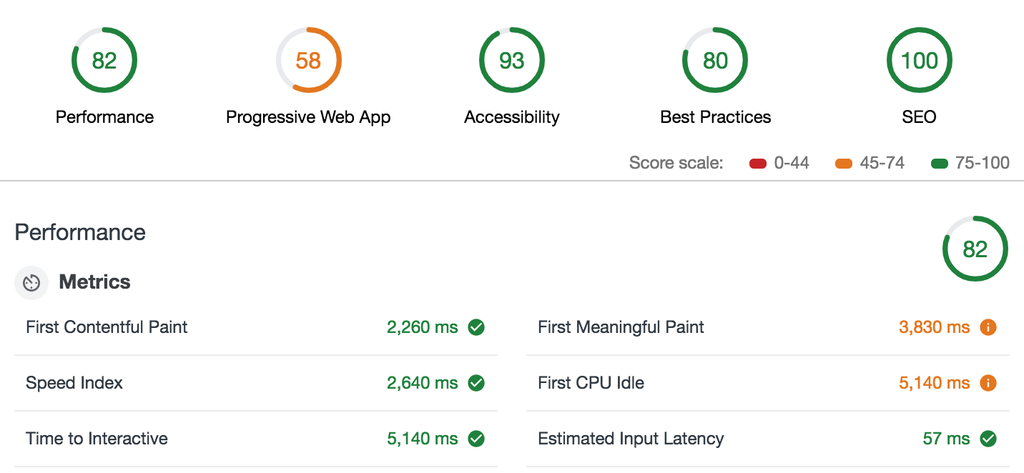

- Eliminate render-blocking resources

One viable solution might be split up the styles into different files, organized by media query, and then adding a media attribute to each stylesheet link, because when loading a page, the browser only blocks the first paint.

- Text is invisible while webfonts are loading

Leverage the font-display CSS feature to ensure text is user-visible while webfonts are loading.

- Does not use HTTP/2 for all of its resources

Make HTTP/2 requests instead of 1!

- Links to cross-origin destinations are unsafe

Add `rel="noopener"` or `rel="noreferrer"` to any external links to improve performance and prevent security vulnerabilities.

/webcompat/with_replies(twitter.com), /webcompat/webcompat.com/(github.com)

- Includes front-end JavaScript libraries with known security vulnerabilities

Some third-party scripts may contain known security vulnerabilities that are easily identified and exploited by attackers. Check how they're used on the app and maybe substitute them: Lo-Dash@3.10.1, Moment.js@2.7.0 .

**Single issue**

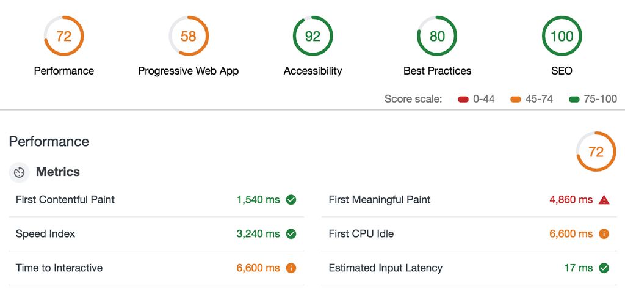

- Defer offscreen images

Consider lazy-loading offscreen and hidden images after all critical resources have finished loading to lower time to interactive. This is a very serious issue it's taking 3s to load the images on this page.

- Serve images in next-gen formats

Image formats like JPEG 2000, JPEG XR, and WebP often provide better compression than PNG or JPEG, which means faster downloads and less data consumption. Another issue that's causing the page take 2.36 s longer to load.

- Properly size images

Serve images that are appropriately-sized to save cellular data and improve load time.

- Text is invisible while webfonts are loading
- Uses inefficient cache policy on static assets

A long cache lifetime can speed up repeat visits to your page. This issue is happening with png files and also with Open Sans font.

- Uses an excessive DOM size

Browser engineers recommend pages contain fewer than ~1,500 DOM nodes.

- Has significant main thread work

Consider reducing the time spent parsing, compiling and executing JS. You may find delivering smaller JS payloads helps with this. Script Evaluation 1,249 ms, Other 785 ms, Style & Layout 449 ms, Rendering 370 ms, Parse HTML & CSS 71 ms, Garbage Collection 47 ms and Script Parsing & Compilation 16 ms.

- Does not use HTTP/2 for all of its resources
- Links to cross-origin destinations are unsafe

mu/mp(mail.google.com), /webcompat/with_replies(twitter.com), /webcompat/webcompat.com/(github.com)

**List of issues**

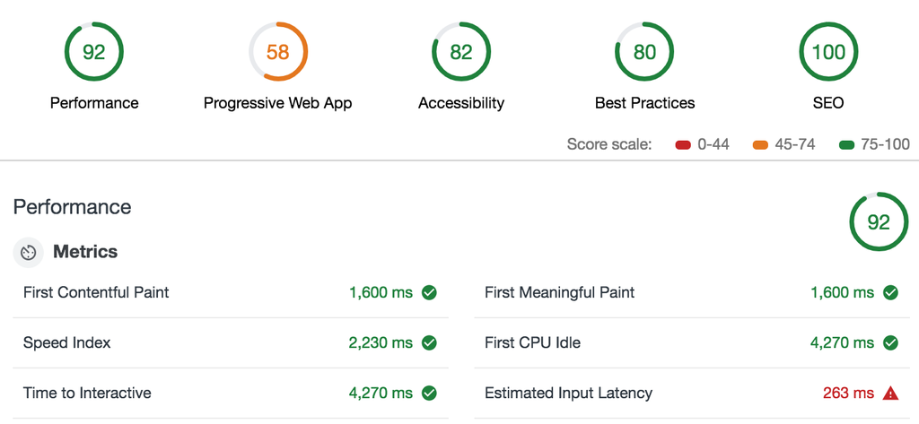

- Text is invisible while webfonts are loading
- Does not use HTTP/2 for all of its resources
- Links to cross-origin destinations are unsafe
- Form elements do not have associated labels

Labels ensure that form controls are announced properly by assistive technologies, like screen readers.

**New issue**

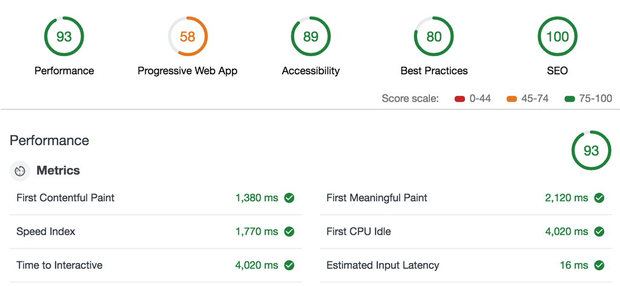

- Eliminate render-blocking resources
- Text is invisible while webfonts are loading
- Does not use HTTP/2 for all of its resources
- Links to cross-origin destinations are unsafe
- Includes front-end JavaScript libraries with known security vulnerabilities

### REDBot

To give a closer look at how Webcompat's HTTP requests were doing I've used a tool called [REDbot](https://redbot.org/), it gave me a couple of useful insights:

**All pages**

- The server's clock is 16 sec ahead.

Referring to the following line: `X-XSS-Protection: 1; mode=block`

- This response prevents some browsers from rendering it within a frame.
- This response blocks XSS attacks in IE8+.
- This response instructs Internet Explorer not to 'sniff' its media type.

**Homepage**

- This response allows a cache to assign its own freshness lifetime.
- This response allows all caches to store it.
- The response body is different when content negotiation happens.

**Single issue**

- The 304 response is missing required headers.

Referring to the following line: `ETag: "b8e7998857de2d3fd77ac68545dbb8bf"`

- The ETag doesn't change between negotiated representations.

**All issues & Search page**

- The response body is different when content negotiation happens.
- The 304 response is missing required headers.
- This response cannot be served by a cache, because it is stale.
- The response body is different when content negotiation happens.
- This response is already stale.
- This response only allows a private cache to store it.

Referring to the following line: `ETag: "b8e7998857de2d3fd77ac68545dbb8bf"`

- The ETag doesn't change between negotiated representations.

**New issue**

- The response body is different when content negotiation happens.
- This response allows all caches to store it.
- This response allows a cache to assign its own freshness lifetime.

### Profilers

Once I found some possible bugs and requests to be optimized the next step is to understand what's happening on a deeper level: where do they come from, what do they eat, can they be fixed? So I decided to run some profilers.

First I tried [cprofile](https://docs.python.org/2/library/profile.html). Cprofile is a great tool and offers a lot of different libraries to visualize its data, I tried a few like gprof2dot, [snakeViz](https://jiffyclub.github.io/snakeviz/), vprof and [Kcachegrind](https://kcachegrind.github.io). I've also experimented with pyflame and [pyvmmonitor](http://www.pyvmmonitor.com/). I'm not going to make a profound analyses using all of them but I'll show the ones that gave me the most comprehensive results. This time I used a Linux because of compatibility issues between Mac and some of the tools I've tested I've also used `Mozilla Firefox for Arch Linux Version 62.0.3 (64-bit)`, the hardware specs can be found here.

I used the following method: after finding out requests that could be problematic I've copied their curl requests and while running the server I've made the requests and used the profilers to have a closer look at what's happening.

#### gprof2dot

After testing a bunch of different visualization tools gprof2dot was my favorite. It not only generates a tree of functions - which makes visualizing the flow much easier - but it also offers within the tree the function calls, the lines where those functions were called and how much processing each one of those functions spent. It's not the best looking of tools, but it's definetly the more complete one.

**Local issue**

While looking at the single issue page I found out that it makes requests to Github API to get information about the labels in Webcompat repository. But for this single issue I'm looking at it's not necessary to make all these requests.

```
  {
    "id": 822983531,
    "node_id": "MDU6TGFiZWw4MjI5ODM1MzE=",
    "url": "https://api.github.com/repos/webcompat/webcompat-tests/labels/type-webrender-enabled",
    "name": "type-webrender-enabled",
    "color": "ededed",
    "default": false
  }
```

I've made a lot of tests using profilers but I didn't find anything really useful. I believe this kind of tool is useful only when you already have a strong hint of what might be the issue and then you use it to measure it. It's more useful for specific searches, so while making this notebook I didn't think it was worth it to invest any more time at this. I think this is a very useful tool, but I'd rather use it when it's really necessary.

# Results

## HTTP 2

I've read a lot about the benefits HTTP2 could bring to a page, so I was really excited to try this. I've used the `prod-server.md` file to configure my own server. I chose to use nginx 1.15.5 which is the latest version available of Ngnix to run tests using HTTP2. As indicated on the file I've used uWSGI to make the connection between Flask and Nginx.

I've used three different devices to run tests on, a Nexus 5, a MacBook and a Sony G8341 all of them using my personal wi-fi network that offers about 5mbps of download speed.

What I learned from this experiment is that, as expected, HTT2 performs better than HTTP1.1. On most of the times I've obtained an improvement of 100ms on loading the first requisitions and another 100ms improvement for loading the first paint, sometimes, like in Nexus 5 mobile the benefit was even bigger, it had an improvement of 410ms on loading the new issue page and 230ms on the homepage.

Another thing that's worth noting is that everytime we push a new `webcompat.min.js` we'd have to update it on the server because the file hash would change. It'd be good if I could automate this.

More detailed info about my results as well as the complete data can be found here. And the code used can be viewed in this [commit](https://github.com/marimeireles/webcompat.com/commit/8ca270fa8b49eae97bfabd7a1d10e75b4bd628cd).

## Markdown-it

Markdown-it is a library that has a lot of uses on Webcompat website and it's called almost on every page. At the very beginning of my analysis I had noticed it was a bottleneck so I started to look for solutions on how to minimize the impact this library had.

I looked for different libraries, how to minify the library, I even looked at Markdown-it's source code to see if I was able to optimize something, but then I found [this](https://developer.github.com/v3/media/#html), the Github API offers a markdown version of the requests! So adding this line to the code `application/vnd.github.v3.html+json` and removing some other that used to call Markdown-it I was able to remove Markdown-it from most pages. The only page I couldn't remove it was the issue page because people can write their own comments using emojis on this page, so Markdown-it is still necessary.

The website had a big improvement in what concerns the total loading time at the homepage it took 978ms less using a 3G fast connection, while the issues page took 770ms less to load.

The time to completely load the DOM was much smaller on the homepage it was 1020ms faster with these changes and on the issues page 1258ms faster.

The time to parse the HTML was also much smaller it droped 67ms on homepage and 134ms on issues.

Even though we had an increase on the standard deviation the other benefits definitly seems worth to pay the price. With these optimizations there is only one page left that uses Markdown-it, we could try to improve its loading by using server side rendering or maybe by looking for a new lib that's lighter.

You can find the code with my changes in this [commit](https://github.com/marimeireles/webcompat.com/commit/e4967d272f9e000a7fbeab134e6a8bb6076e7182).

## List of issues

The main objective of webcompat.com/issues is to show issues and I've realized they were taking a great amount of time to appear to the user.

While running tests using Chrome DevTools I found that `issue.js` was acting as a render-blocking file. It was being processed at Parse HTML. While parsing HTML the browser shouldn't compile any JS scripts, so what I did was adding `window.onload` to try to take it out of the browser's way and it end up improving the first paint time 127ms. It also decreased the total time spent parsing the document from 40% to 20% and also a little bit from XHR loading from 32% to 285. This time was transferred to the `Evaluate script` time, which is the right thing. The total loading time of the page didn't decrease, but since I didn't do any optimization in the sense of decreasing the time, only arranging it so it could load at the right time, it was expected. The objective here was diminishing the first painting time and it worked.

I tried to minimize the external influences in my results so I've copied the response of the HTTP request made by `issues-list.js` and pasted it directly on my code, so my results weren't affected by my internet connection. You can see the data and my methodology to obtain it on this session and the code can be found in this [commit](https://github.com/marimeireles/webcompat.com/commit/ab2c6ea7672f5562f6b407b76d6307b44d6bf687).

## Homepage

I identified `bugform.js` and `untriaged.js` as two possible bottlenecks on the loading of homepage, the same way as was happening at list of issues. So I ran some tests and I found out that only `bugform.js` was a real problem, when I tried to make both files wait till the end of parsing to load I had a decrease in the performance so what I did was simply add `window.onload` to `bugform.js`and the time to show the first paint decreased by 138ms.

A commit containing the code change can be found [here](https://github.com/marimeireles/webcompat.com/commit/ea290b23f6d9df781a4d79e3daaec4c2d0c16b9a).

Another thing I've come up with while analyzing the homepage was that it was fetching 30 issues from Github. This isn't necessary in view of the homepage only shows 5 issues at a time. This was happening because when you do a request to Github and don't pass any parameter to it, it will [fetch 30 issues by default](https://api.github.com/repos/marimeireles/webcompat-tests/issues). To fix that I've added `+ '?per_page=5'` to `/issues/category/<issue_category>` endpoint. That improved the time to download the issues from 991ms and 136kb to 681ms and 23kb, a decrease of about 6x as expected or 310ms. This can mean a significant improvement for mobile users since they usually lack good internet connection.

# Future implementations in details

## Fonts

An interesting thing we could do is try to use `@font-face` using the `local` directive we can search in the device if the font exists before trying to download it. It's also possible to set the `unicode-range descriptor` which restricts the unicode range, fonttools can help us create a subset that fits our needs.

We could also use `<link rel="preload">` on the HTML `<head>` to load the fonts in the beginning of the loading process instead of waiting the CSSOM to be created. Most of the text is already being loaded before other less important elements, but the main text for example in homepage is loaded after some other less important files are loaded like the leafs.svg, ga.js and analytics.js.

In the end we'd have something like:

```
<head>
  <!-- Other tags... -->
  <link rel="preload" href="/fonts/OpenSans-Regular.woff2" as="font">
</head>

@font-face {
  font-family: 'Open Sans', sans-serif;
  font-style: normal;
  font-weight: 400;
  src: local('opensans Font'),
       url('/fonts/OpenSans-Regular.woff2') format('woff2'), /* will be preloaded */
       url('/fonts/OpenSans-Regular.woff') format('woff'),
       url('/fonts/OpenSans-Regular.ttf') format('truetype'),
       url('/fonts/OpenSans-Regular.eot') format('embedded-opentype');
  unicode-range: U+000-5FF; /* Latin glyphs */
}
```

It'd still be possible to use [Web Font Loader](https://github.com/typekit/webfontloader) to load fonts asynchronously. Or as an alternative to that we could try [Font Face Observer](https://github.com/bramstein/fontfaceobserver) which is a is a small `@font-face` loader and monitor, according to [keycdn.com](https://www.keycdn.com/blog/web-font-performance) "They were able to decrease the time at which their font starts painting from 2.7 seconds down to 300ms."

Besides that I thought about other two things that we could do: either we download the font and host it on our own webserver or we keep using it the way we are. There are ups and down sides for both of these approaches.

An upside of keeping it hosted on Google is that we would have their support so we wouldn't have to worry about keeping them updated, also we'd have access to their CDNs, hosting our fonts locally may no longer be the best solution because we want the font to be downloaded from a location in closer proximity to the user. On the other hand looking at so many Network and Performance tests as I've done, I've seen how much time we tend to loose on these font requests (about 400ms per page on average).

Even though hosting the fonts locally doesn't guarantee that we'd have lower request times it may be worth a try. We could optimize the way fonts are zipped to try to reduce its time. According to [WOFF2.0 Evaluation Report](https://www.w3.org/TR/WOFF20ER/#appendixA) appendices A and B, compressing Opensans's using Brotli would decrease its size by 25\% and zipping Source Sans Pro's using LZMA would decrease 26\%. Having smaller fonts would surely decrease the time we spent downloading them.

## Multiple files and layout thrashing

I've tested all of Webcompat subpages and all of them have at least three different JS files and two CSS. Having just one JS file and one CSS file eliminates network roundtrips - it could mean a major gain for users in high-latency network environments (international and mobile). In addition, multiple stylesheets cause layout thrashing.

Testing on my Mac with my 5mb internet I've counted eight calls to the Layout event that sums to 101ms of the page rendering time. Joining these files together could give us a considerable improvement on mobile processing.

Making a quick search I found we don't use many `float` options through the code, which is good because it diminishes the effect of Layout recalculation. I also saw that we're using `flex` attributes in a bunch of other places which is great, according to this [Google article](https://developers.google.com/web/fundamentals/performance/rendering/avoid-large-complex-layouts-and-layout-thrashing?hl=en#use_flexbox_over_older_layout_models) about improving performance building a `Flex` design over other designs could improve the rendering speed by incredible 400\% (if you're using a complete `float` based design). So it might be worthwhile of our time to take a look at the CSS code all over again and check if there is something we can flex also it'd be useful to check if we're using too many layout attributes to try to minimize layout thrashing. I believe that eight calls are too many calls for our `/issues` page and this number could be minimized.

## Minifying and bundling

There are some files that aren't minified, like HTML and JS files in various pages. I've already found some options[[1](https://github.com/gruntjs/grunt-contrib-htmlmin)][[2](https://github.com/sindresorhus/grunt-minify-html)] to minify HTML files using Gruntfile. It wouldn't cost much for us to do it because we wouldn't have to add a new dependency to the project we'd just have o alter the `gruntfile.js` to generate these minified HTMLs.

Another thing we could try is minifying files using this [ngnix module](https://github.com/google/ngx_brotli) that compress files using Brotli. Brotli is 20 - 30% better than Gzip, but it's supported for fewer browsers, still we could use it for users that owns newer browsers, it'd surely be a huge improvement for mobile users with poor internet connection. If we use this module is better to set Brotli’s compression level [4 is both faster than the Gzip’s default level and compresses better](https://certsimple.com/blog/nginx-brotli).

## Preloading

In order to preloading to work is necessary to have a site with a good SEO, so that's another optimization we should think about. We could use the tag `<link rel="dns-prefetch">` on HTML to load Google fonts and `<link rel="preload">` or `<link rel="prerender">` to load the big `webcompat.min` bundles. It's necessary to be careful when using these tags because they still consumes visitor’s traffic and that could mean a worsen for mobile users. Even so it seems like a promising resource.

## Image compressing

I believe we could change images on the single issue page from PNG to JPG format because it's not necessary to mantain a lossless format for them. After that we could still compress quality to 70-80 and make [progressive image rendering](https://blog.codinghorror.com/progressive-image-rendering/).

The SVG images on the website could be minified, since SVG is a kind of text. We could also use a tool like svgo to see if there is any redundant or useless information on our files.

## Progressive Apps

As seen on the Lighthouse report all of Webcompat pages had the same problem. Analyzing Webcompat code I found out the site has a `.webmanifest`, which means it intends to be a Progressive App.

## Cache

As the analysis made using Test my site, Lighthouse and REDbot show we're not making the best use possible of cache. It's important to think in a solution to this issue because improving caching could mean removing a significant wait time for mobile users.

First we could start at setting expiry time (or other age-controlling header set) to the pertinent files. This is a sketch of how to configure Cache-Control and Expires Headers in a Nginx server:

```
. . .
# Default server configuration
#

# Expires map
map $sent_http_content_type $expires {
    default                    off;
    text/html                  epoch;
    text/css                   max;
    application/javascript     max;
    ~image/                    max;
}

server {
    listen 80 default_server;
    listen [::]:80 default_server;

    expires $expires;
. . .
```

Besides we could store svg and font files it's also advisible to store pages that don’t change like the 404, or the single issue pages that were already closed. To make these changes we could use [Varnish](https://www.varnish-software.com/about-us/) it offers support to Ngnix and they seem to integrate well.

# Timeline

**Week 1**

Implement changes I proposed on the Results session. The working code is already written, I believe the most complicated thing would be update the server. Also, this week will be my first week so I'll spend sometime getting used to the team routine.

**Week 2**

Expand and implement ideas related to fonts, I already have some hacks and sketches I made, but I need to make them pretty. Optimize images in the website.

**Week 3, 4**

Work to improve Cache and create server side rendering, I'll have to do a lot of testing that will take some time at this part to see if all of my ideas are worth pursuing.

**Week 5**

Work on SEO, test and create preloading for Webcompat.

**Week 6, 7**

Learn more about progressive apps and implement optimizations related to it.

**Week 8, 9**

Deal with layout thrashing and multiple files.

**Week 10, 11, 12**

I'm sure I'll learn a lot of other interesting things while I'm researching and implementing the topics above so I want to have some "free time" in my schedule to be able to do things I haven't thought of yet.

I think this would also be a good time to run some profilers like PyFlame and Kcachegrind to try to optimize key parts of the code.

I believe I've covered the main parts of website optimization with this timeline but these three last weeks should be enough in case I missed some other important part.

# Appendix

## Hardware specifications

### Nexus 5

```
Device model: Nexus 5
Android version: 7.1.2
LineageOS version: 14.1
CPU processor: Quad-core 2.3 GHz Krait 400
RAM memory: 2 GB
```

Using Nexus 5 was specially good because it's representative: it has the most used OS[[1](https://www.statista.com/statistics/271774/share-of-android-platforms-on-mobile-devices-with-android-os/)][[2](https://fossbytes.com/most-popular-android-versions-always-updated/)] and I've tried it using the most common kind of internet connection[[1](https://tribune.com.pk/story/1644005/2-number-3g-4g-users-reaches-49-5m-jan-2018/)][[2](https://fp.brecorder.com/2018/05/20180523373714/)] in the world.

### Sony G8341

```
Device model: Sony G8341
Android version: 8.0.0
CPU: Octa-Core, 2 processors:
     2.35Ghz Quad-Core Kryo
     1.9Ghz Quad-Core Kryo
RAM memory: 4GB LPDDR4
```

### MacBook

```
Device: MacBook Pro (Retina, Mid 2012)
Memory: 16 GB 1600 MHz DDR3
CPU: Processor of 2,6 GHz Intel Core i7
```

### Asus x450c

```
Device: Asus x450c
Memory: 3.7 GiB
CPU: Processor Intel Core i5-337u CPU @ 1.80GHz x 4
```